# Has Hawaii’s Public Health Measures Triumped over Covid? Forecasting Hawaii’s Covid Cases

## Status: Working Document

Hi everyone. I’m continuing building my data analysis and R skills. As such, I would love feedback to better improve this project via rexmanglicmot@gmail.com. Any mistakes and misrepresentation of the data are my own.

Things still need to do:

1. Forecast negative cases in ARIMA and Prophet
2. Ask for feedback on models for additonal analysis
3. Fill in missing sections to round out project
4. Check grammar

### Introduction

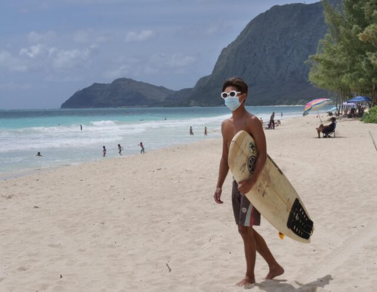

Since the dawn of the pandemic in early March 2020, the world experienced an unprecedented pandemic. With the sudden appearance of Covid, many countries reacted swiftly on past pubic health protocols to help slowdown the spread of Covid. Some of these protocols were government lock downs, encouragement of praticing health hygiene (i.e. wear masks), stay in-doors, etc. Further, news outlets, brochures, and highly educated public health officials advocated the implementation of such protocols. As result, 3 years after, it would seem that the world has weathered the storm and move on from this pandemic. Many news stories have focused their topcis on other issues, which implies that the Covid pandemic is under control.

But, is there a way to quantitatively measure this? Has the world truly overcome the Covid pandemic? This projects aims to understand if Covid still exists, more specifically, in the context of the Hawaiian Islands by measuring the number of positive and negative cases. By measuring the aforementioned, 1) we can indirectly surmise if Hawaii’s public safety protocols had any effects and 2) make adjustments to protocols for better health outcomes.

This project will forecast based on two models: ARIMA and Prophet. By comparing and contrasting these two models, we can determine if the forecasts project upward, downward, or parralll. Having this provides public health officials ample time to plan health initiatives (i.e. testing centers) and procure necessary medical in the future (needles, gauzes, bandages, etc.).

This project is structured in the following chapters:

1. Loading the Libraries
2. Cleaning the Data
3. Exploratory Data Analysis
4. Forecasting: ARIMA
5. Forecasting: Prophet
6. Limitations
7. Conclusion
8. Appendix: ACF and PACF Concepts and Plots

Special acknowledgement to Healthdata.gov[^1] providing the dataset to the public. This dataset includes COVID-19 Laboratory test (PCR) results from over 1,000 US labs and testing locations (public and private). Data are reported to state departments which are then reported to federal departments per the CARES Act. Each state is represented.

The variables of the dataset are as follows:

1. state (string) - Abbreviation of state associated with the test.
2. state_name (string) - Name of state associated with the test.
3. state_fips (string) - Numerical identifier of state associated with the test.
4. fema_region (string) - Region associated with the test.
5. overall_outcome (string) - Outcome of test – Positive, Negative or Inconclusive.
6. date (date) - Typically the date the test completed or the date that the result was reported back to the patient. If neither are available, it can be the date the specimen was collected, arrived at the testing facility, or the date the test was ordered. 7.new_results_reported (long) - The number of tests completed with the specified outcome in the specified state on the listed date. (Large spikes may result from states submitting tests for several proceeding days at once with a single date).
7. total_results_reported (long) - The cumulative number of tests completed with the specified outcome in the specified state up through the listed date.
8. geocoded_state - indiscernible

### Loading the Libraries

```r
#install.packages('jsonlite') #installed on 11/24/22
#install.packages('data.table') #installed on 11/24/22
#install.packages('httr') #installed on 11/24/22
#install.packages('timetk') #installed on 11/25/22

library(tidyverse)
library(xts)
library(timetk)
library(forecast)

#read data from CSV file from U.S. Government website
data <- read.csv('COVID-19_Diagnostic_Laboratory_Testing__PCR_Testing__Time_Series.csv')
```

### Cleaning the Data

Now that we have loaded the libraries and uploaded the data, it is time look at the structure of the data to understand how the data is organized.

```r
#check structure of the dataset
str(data)
```

```
'data.frame':   162225 obs. of  9 variables:
 $ state                 : chr  "AL" "AL" "AL" "AL" ...
 $ state_name            : chr  "Alabama" "Alabama" "Alabama" "Alabama" ...
 $ state_fips            : int  1 1 1 1 1 1 1 1 1 1 ...
 $ fema_region           : chr  "Region 4" "Region 4" "Region 4" "Region 4" ...
 $ overall_outcome       : chr  "Negative" "Positive" "Negative" "Positive" ...
 $ date                  : chr  "2020/03/01" "2020/03/01" "2020/03/02" "2020/03/02" ...
 $ new_results_reported  : int  96 16 72 6 94 9 0 2 61 6 ...
 $ total_results_reported: int  96 16 168 22 262 31 262 33 323 39 ...
 $ geocoded_state        : logi  NA NA NA NA NA NA ...
```

```r
#check the class of the dataset; it is a dataframe class
class(data)
```

```
[1] "data.frame"
```

With a high-level overview, we see that are dealing with a large dataset that contains over >100K observations with 9 variables. Each of these observations pertain to the U.S. States. Some of the variables are character strings like the state variable while others are integers like new_results_reported. Also we see that the date frequency is daily, knowing this helps us build the forecasting models.

Moving forward with the scope of the project, we want to do a time series analysis and as such, we see that the date column is a character and needs to be formated to a Date class.

```r
#change column from a character string to a date column
data$date <- as.Date(data$date)

#check data now
str(data)
```

```
'data.frame':   162225 obs. of  9 variables:
 $ state                 : chr  "AL" "AL" "AL" "AL" ...
 $ state_name            : chr  "Alabama" "Alabama" "Alabama" "Alabama" ...
 $ state_fips            : int  1 1 1 1 1 1 1 1 1 1 ...
 $ fema_region           : chr  "Region 4" "Region 4" "Region 4" "Region 4" ...
 $ overall_outcome       : chr  "Negative" "Positive" "Negative" "Positive" ...
 $ date                  : Date, format: "2020-03-01" "2020-03-01" ...
 $ new_results_reported  : int  96 16 72 6 94 9 0 2 61 6 ...
 $ total_results_reported: int  96 16 168 22 262 31 262 33 323 39 ...
 $ geocoded_state        : logi  NA NA NA NA NA NA ...
```

We see that the date column has been converted to the proper universal date format.

Now, we want filter the dataset in this order:

1. Filter for the state of Hawaii.
2. Arrange the number of cases of both positive and negative outcomes and erase of the inconclusive value.
3. Then remove unnecessary variables such as state, state_name, state_flips, fema_region, and geocoded_state
4. Store this into a new object.

```r
#filter for hawaii state now
data_HI <- data %>%
  filter(state == 'HI') %>%
  filter(overall_outcome != 'Inconclusive') %>%
  arrange(overall_outcome) %>%
  dplyr::select(-c(1:4,9))

head(data_HI, 5)
```

|  | overall_outcome | date | new_results_reported | total_results_reported |
| --- | --- | --- | --- | --- |
| 1 | Negative | 2020-03-02 | 1 | 1 |
| 2 | Negative | 2020-03-03 | 4 | 5 |
| 3 | Negative | 2020-03-04 | 0 | 5 |
| 4 | Negative | 2020-03-05 | 0 | 5 |
| 5 | Negative | 2020-03-06 | 1 | 6 |

Now, let’s filter some more.

1. Create two objects of both positive and negative cases.
2. Remove the new_results_reported since we are only interested in the total reported cases since it is additive.
3. Convert the remain columns, total results_reported, to a time series.
4. Store this into a new object.

```r
#filter for positve and delete unnessary variables and
#create a timeseries for forecasting
data_HI_pos <- data_HI %>%
  filter(overall_outcome == 'Positive') %>%
  dplyr::select(-c(1,3)) %>%
  tk_xts(select = total_results_reported)
```

Now, let’s check if the filtering work and if we have a time series.

```r
#check class for positive cases
head(data_HI_pos, 5)
```

```
           total_results_reported
2020-03-13                      1
2020-03-14                      3
2020-03-15                      6
2020-03-16                      6
2020-03-17                     10
```

```r
class(data_HI_pos)
```

```
[1] "xts" "zoo"
```

It look’s good. Now, let’s repeat the same process for the negative cases

```r
#filter for negative and delete unnessary variables and
#create a timeseries for forecasting
data_HI_neg <- data_HI %>%
  filter(overall_outcome == 'Negative') %>%
  dplyr::select(-c(1,3)) %>%
    tk_xts(select = total_results_reported)
```

```r
#check class for negative cases
head(data_HI_neg, 5)
```

```
           total_results_reported
2020-03-02                      1
2020-03-03                      5
2020-03-04                      5
2020-03-05                      5
2020-03-06                      6
```

```r
class(data_HI_neg)
```

```
[1] "xts" "zoo"
```

Great! Now, that the data have been cleaned and filtered, it is time to explore the two datasets which we created: data_HI_pos and data_HI_neg.

### Exploratory Data Analysis

Let’s plot the positive cases.

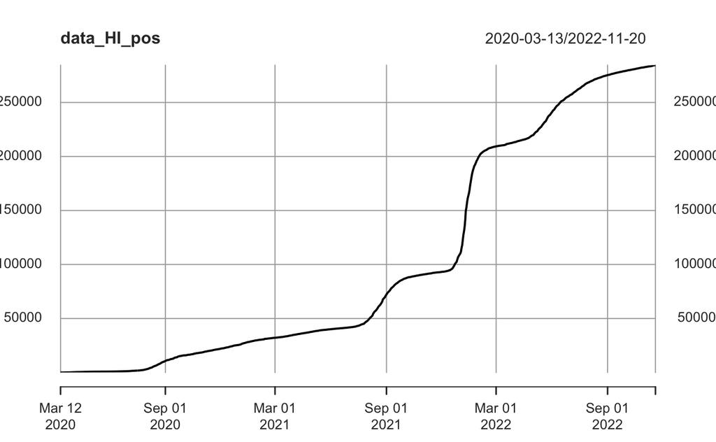

```r
#Plot positive cases
plot(data_HI_pos)
```

Yikes! Based on the count alone, it seems that this plot is showing that the number of positive cases are increasing. However, because there is a big gap of counts, there is a need to log it. Logging the count will provide a better context to see the trend of positive cases.

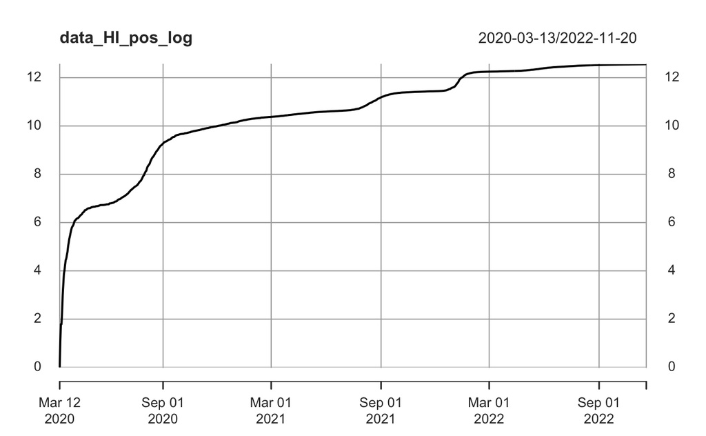

```r
#log and plot again
data_HI_pos_log <-log(data_HI_pos)
plot(data_HI_pos_log)
```

This is a much better plot. From this, let’s gather a few insights.

1. We see from the beginning of the pandemic there there was a sudden surge of positive cases in March 2020 (this was expected). Then, during the months of the following summer we see that the slope drastically increased until Sept 202.
2. From Sept 2020, we see that the slope is still positive, trending upward, but not as pronounced as the March 2020. We see a similar trend from from Feb 2022 onward.
3. A key insight from this plot is that Covid might follow a seasonal trend such that it may come every year.

Now, let’s plot the negative cases.

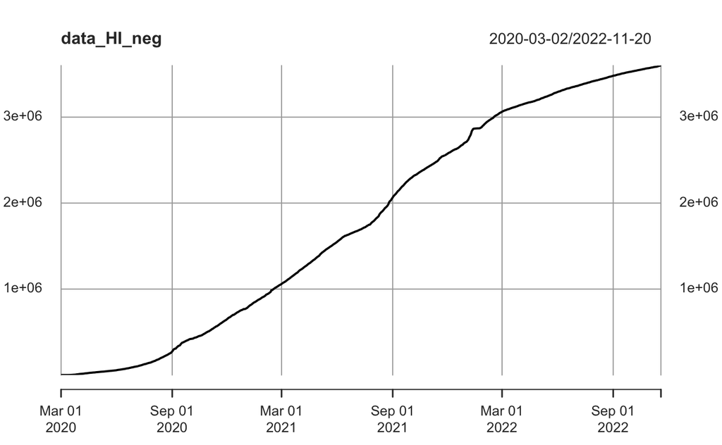

```r
#Plot negative cases
plot(data_HI_neg)
```

Again, from this plot wee see that the cases are increasing and paints the picture that because we are having a high number of negative cases, it could convey that Hawaii covid incidence is low. However, we must log the negatve cases to get a better idea of what the data is trying to convey.

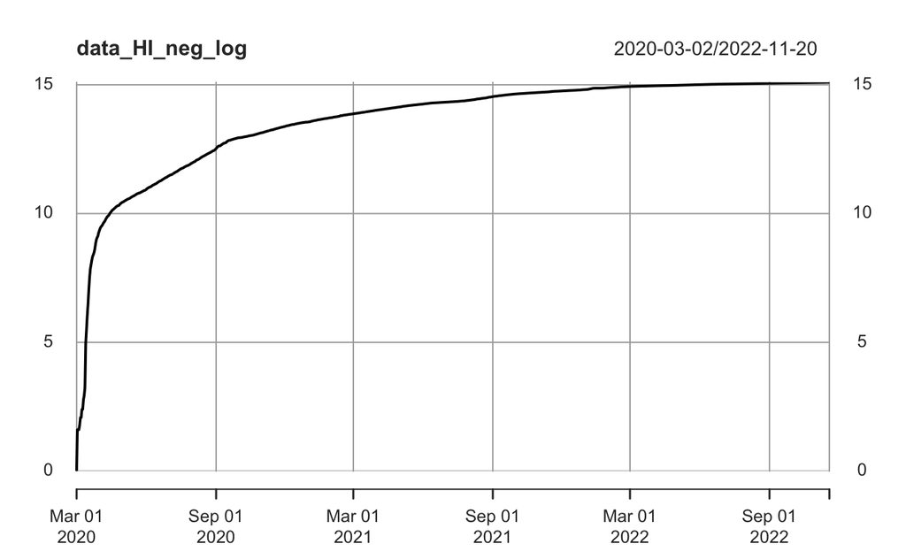

```r
#log and plot again
data_HI_neg_log <-log(data_HI_neg)
plot(data_HI_neg_log)
```

This is a much better plot. From this, let’s gather a few insights.

1. The number of negative cases increased dramatically from March 2020 tp Sept 2020. Again, this expected. Covid during this time was still being researched and not much was known about the virus, how it spreads, etc. Many people knew that it was highly contagious and if you had a fever and were coughing it was best to get tests. As such, during this time people were getting sick and wanted to take tests to see if there were positive for Covid.
2. From Sept 2020 to March 2021, we see that the number of cases were increasing but the slope is not as pronounced.
3. From March 2022 to 11 2022, the slope all but parallel.

Now, based on these trends, let’s forecast both datasets. But first, let’s dive deeper into conceptual knowledge of ARIMA.